# Wilcoxon War

## Prolog

Um das Prinzip von p-Werten zu erklären, habe ich auf meinem Blog die Bewertungen von zwei Burgerläden miteinander verglichen. Die Läden wurden auf einer Skala von 1 - 10 bewertet. Siehe Blogpost hier. Dann kam auf Twitter die Rückfrage, ob ich nicht wegen der ordinalskalierten Daten eigentlich einen Wilcoxon-Test hätte rechnen müssen. Aber erstens habe ich die Daten aus einer Normalverteilung gezogen und weiß, dass sie intervallskaliert sind. Und zweitens habe ich mich an Fagerland (2012) erinnert, der gezeigt hat, dass der Wilcoxon-Test bei schiefen Verteilungen irgendwann $100 % p < .05$ ausspuckt, während der t-Test konstant bleibt.

Erst wollte ich also beweisen, dass der t-Test in meiner Simulation eine angemessene Wahl war (#1). Hätte aber erwartet, dass der Wilcoxon-Test mit steigender Stichprobengröße doof wird. Was aber nicht passiert ist. Weswegen #2 - #5 ein heiliger Krieg sind, den Wilcoxon-Test kaputt zu kriegen.

### Die Simulation

Aus einer Population von 10 Millionen Burgerladenbewertungen werden zwei Gruppen gezogen, wobei nach der ersten Gruppe “zurückgelegt” wird, d.h. die beiden Gruppen stammen nicht aus derselben, sondern identischen Populationen (#1 - #3). Weil das nicht reichte, sind die Gruppen #4 und #5 aus zwei verschiedenen Populationen mit demselben Mittelwert, aber unterschiedlichen Eigenschaften gezogen. Stichprobengrößen sind jedes Mal (pro Gruppe): 10, 50, 100, 200, 500, 1000, 2000, 3000, 4000. Für jede Gruppengröße wird je 10.000 Mal ein t-Test und ein Wilcoxon-Test gerechnet.

## 01 - default

Normalverteilung; ganze Zahlen von 1 - 10. Population 1 und 2 sind identisch.

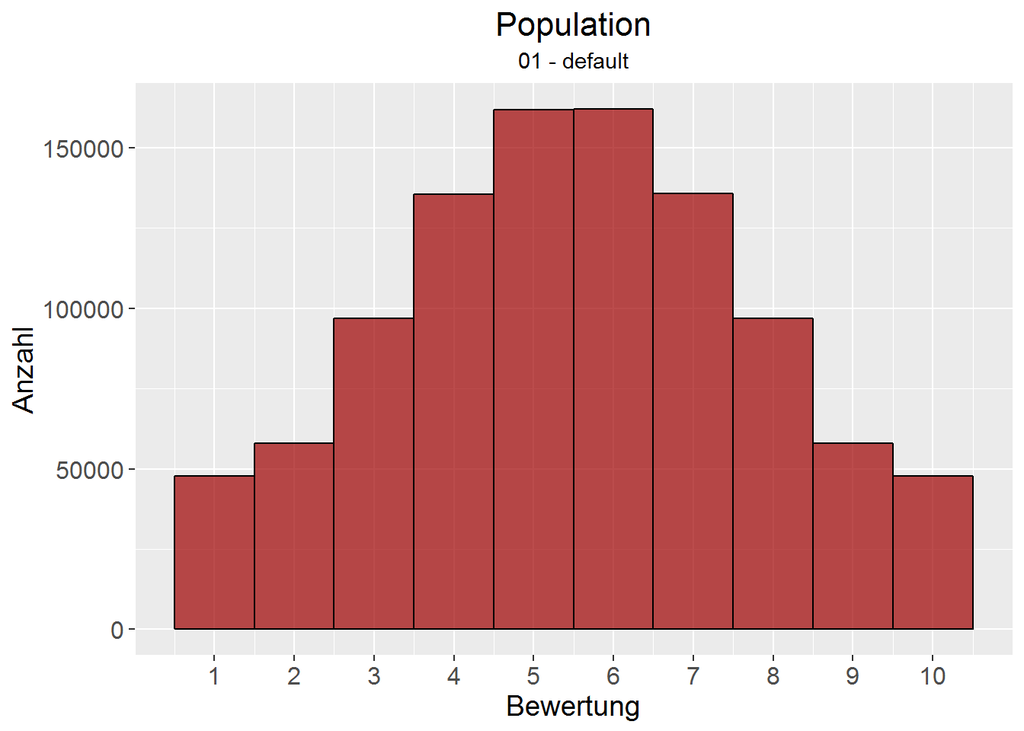

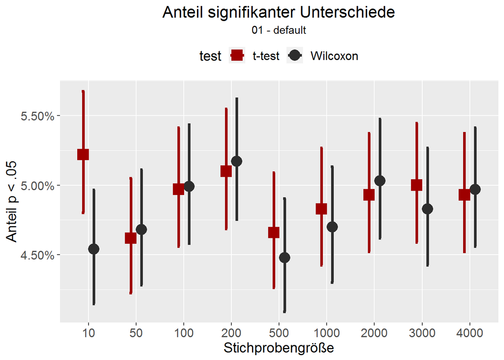

## 02 - ordinalskaliert

Dieselbe Population wie in #01, aber umkodiert in ein hässliches ordinalskaliertes Schema:

| alte Punktzahl | Label | neue Punktzahl |
| --- | --- | --- |
| 1 - 4 | unterdurchschnittlich | 1 |
| 5 - 8 | gut | 2 |
| 9 - 10 | extraklasse | 3 |

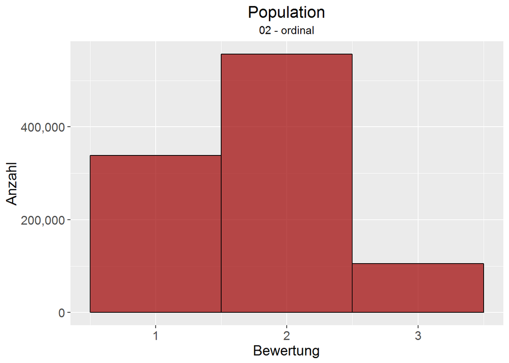

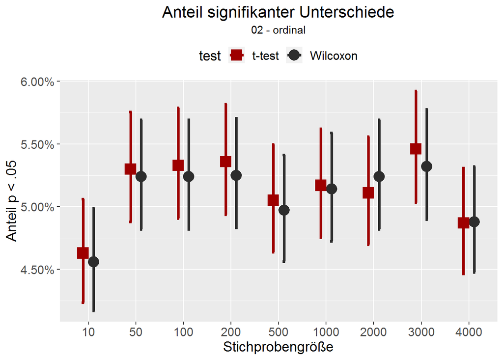

## 03 - lognormal

Extrem schiefe Lognormalverteilung (skew = 7.48). Diesmal keine Umkodierung in ganze Zahlen. Nach wie vor beide Populationen identisch.

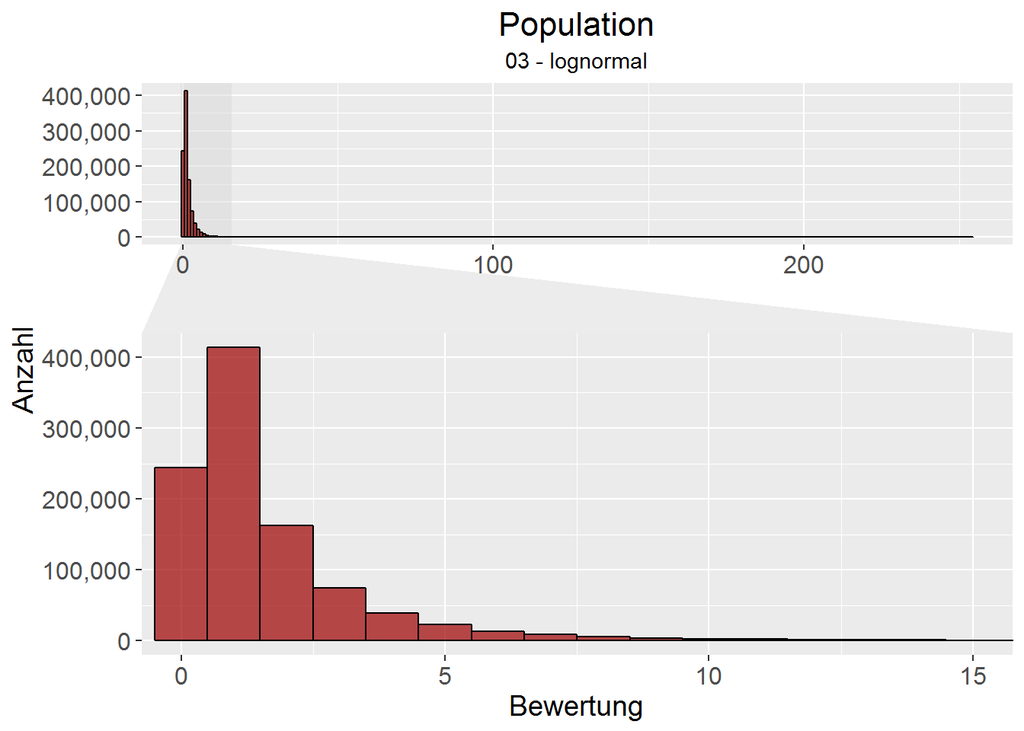

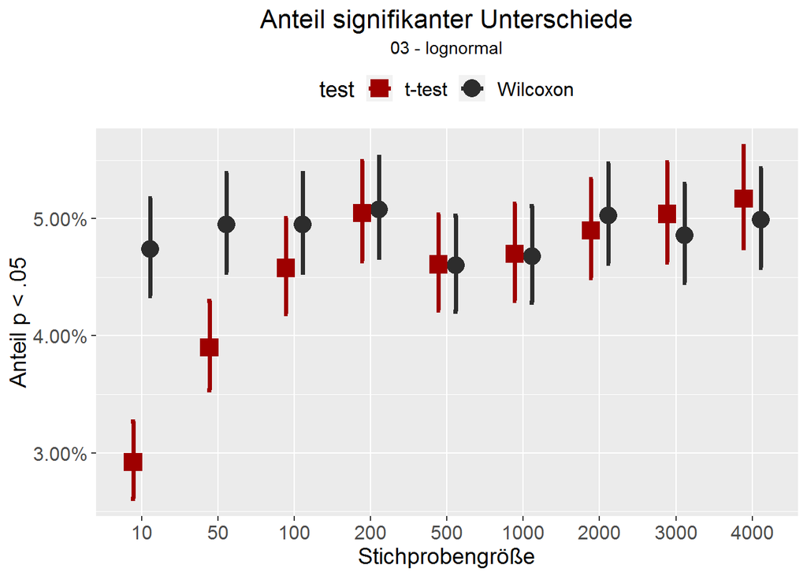

## 04 - unterschiedliche SDs

Unterschiedliche Standardabweichungen in den Populationen. Direkt nach dem Sampeln der Populationen (normalverteilt): Population 1 $(M = 5.50$, $SD = 0.50)$; Population 2 $(M = 5.51$, $SD = 3.00)$. Nach Umkodierung in ganze Zahlen von 1 - 10: Population 1 $(M = 5.50$, $SD = 0.58)$; Population 2 $(M = 5.50$, $SD = 2.67)$.

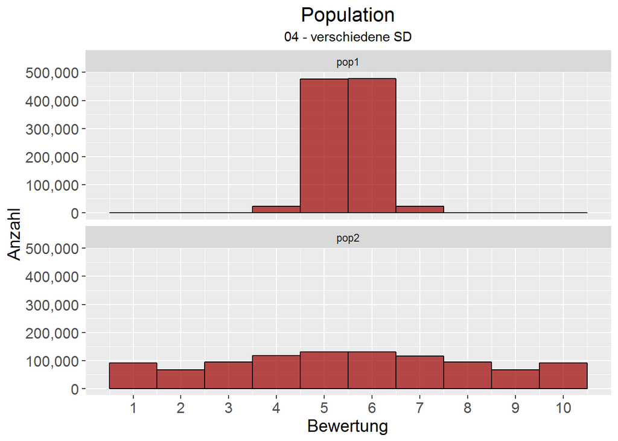

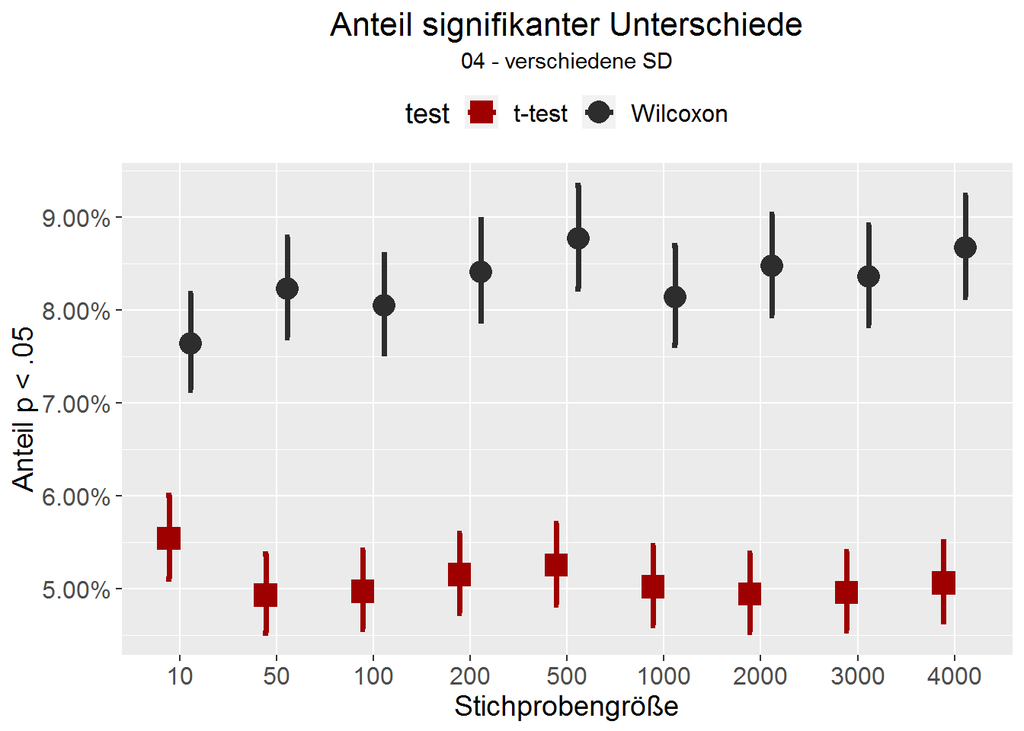

## 05 - Zwei unterschiedliche Lognormalverteilungen

Ungefähre Replikation von Fagerland (2012): Zwei Lognormalverteilungen mit unterschiedlicher SD. Population 2 wurde verschoben, damit sie denselben Mittelwert hat. Population 1: $(M = 1.30$, $SD = 1.07)$, skew = 3.13; Population 2: $(M = 1.30$, $SD = 0.32)$, skew = 0.95.

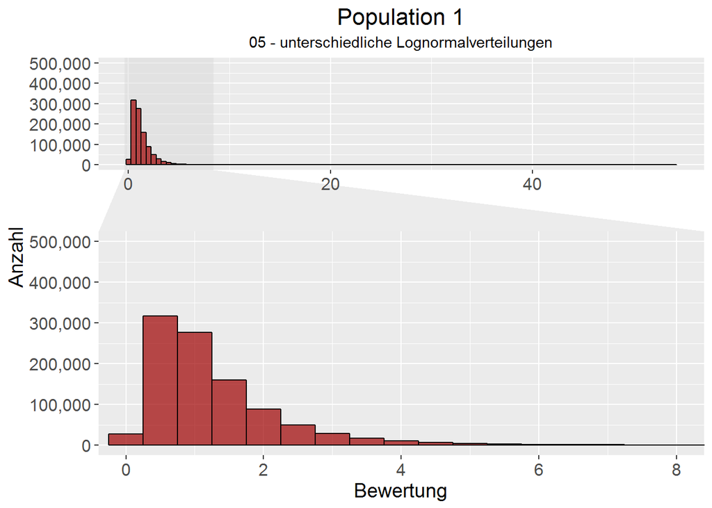

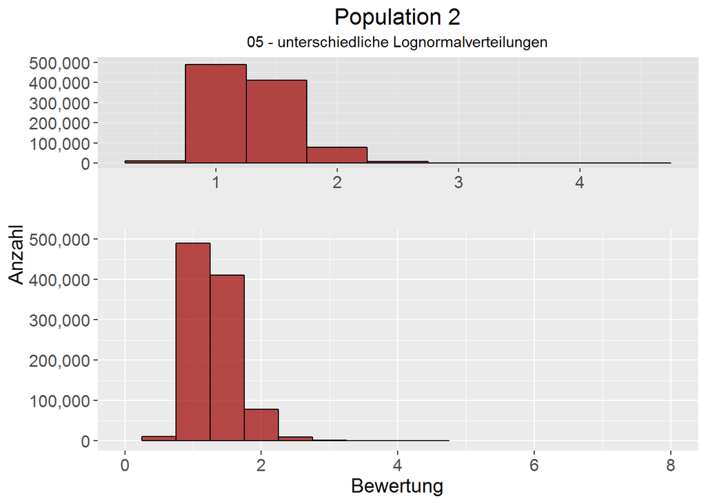

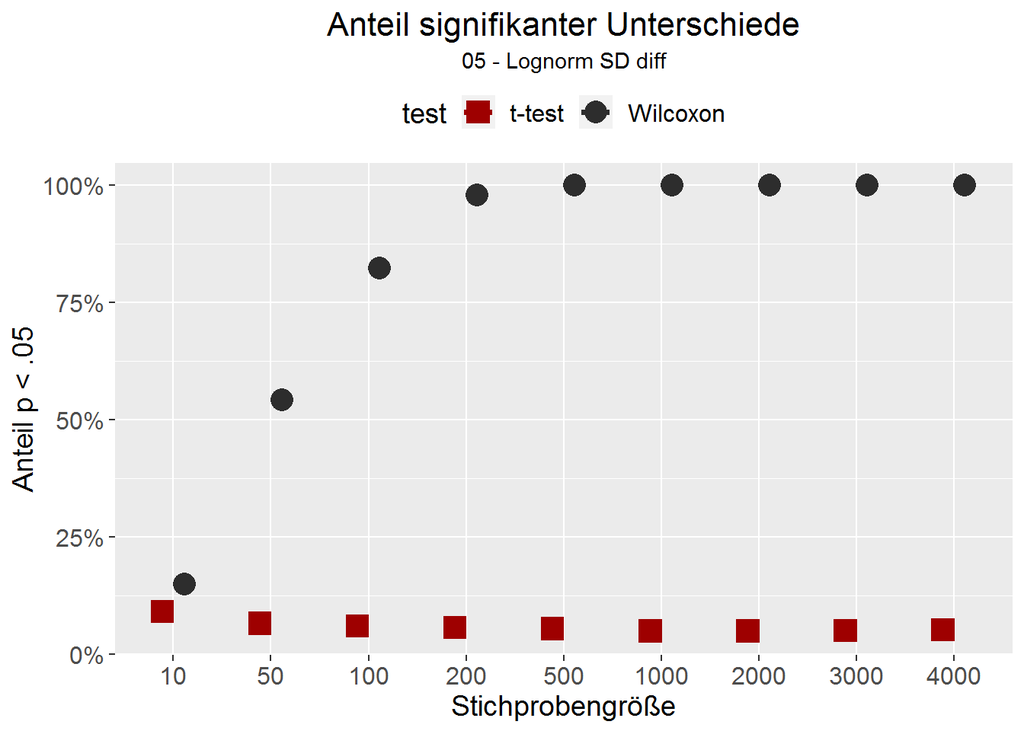

## 06 - Zwei unterschiedliche Gammaverteilungen

Ungefähre Replikation von Fagerland (2012): Zwei Gammaverteilungen mit unterschiedlicher SD. Population 2 wurde verschoben, damit sie denselben Mittelwert hat. Population 1: $(M = 0.24$, $SD = 0.49)$, skew = 4.09; Population 2: $(M = 0.24$, $SD = 0.65)$, skew = 3.07.

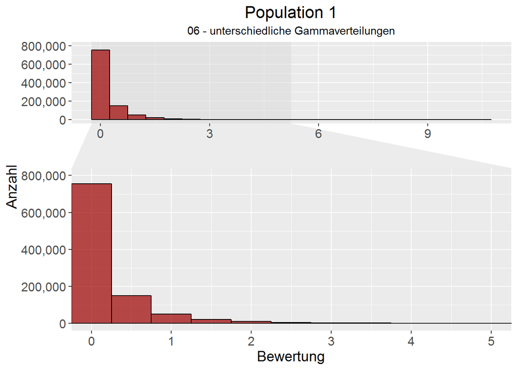

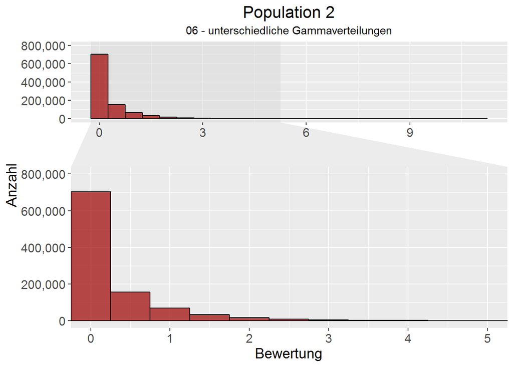

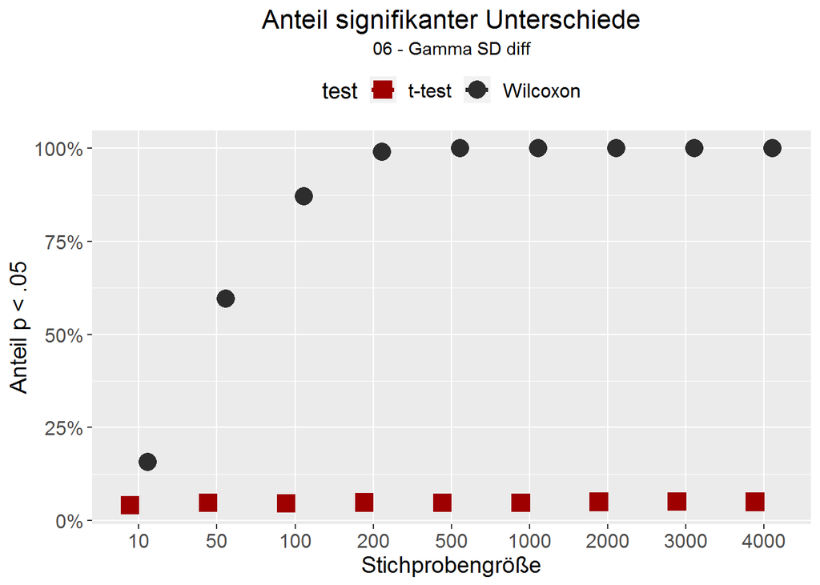

## 07 - Fagerland Eskalation

Beide in Fagerland (2012) erwähnte Verteilungen vereint: Eine Lognormalverteilung (Population 1), eine Gammaverteilung (Population 2). Population 2 wurde verschoben, damit sie denselben Mittelwert hat. Skewness wurde für beide bei etwa 3 gehalten. Population 1: $(M = 1.30$, $SD = 1.07)$, skew = 3.13; Population 1: $(M = 1.30$, $SD = 0.65)$, skew = 3.07.

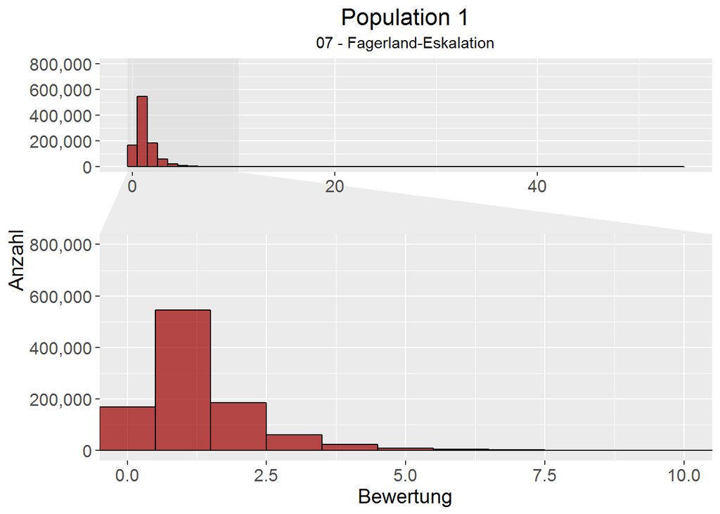

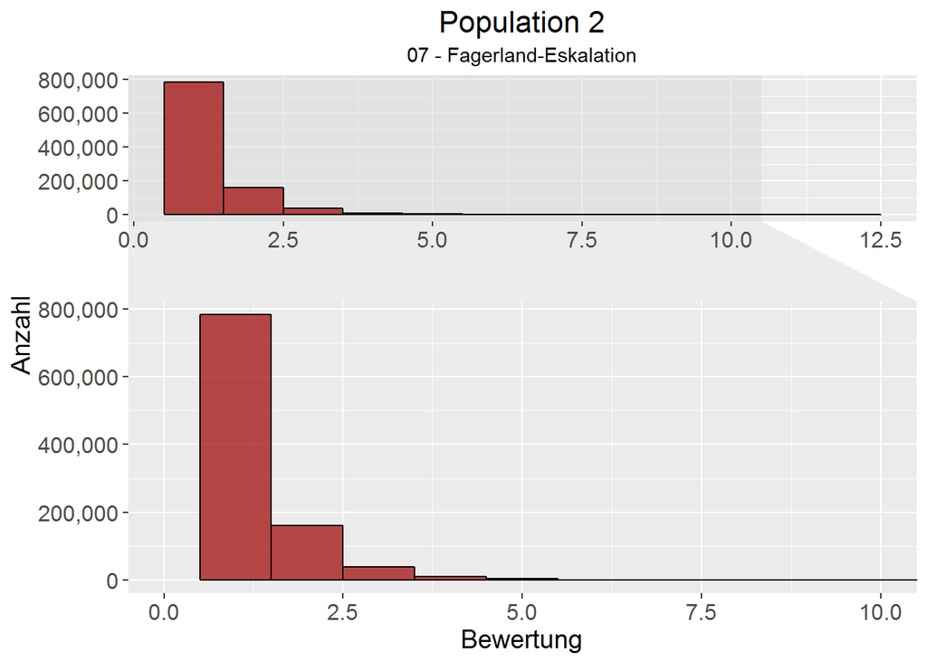

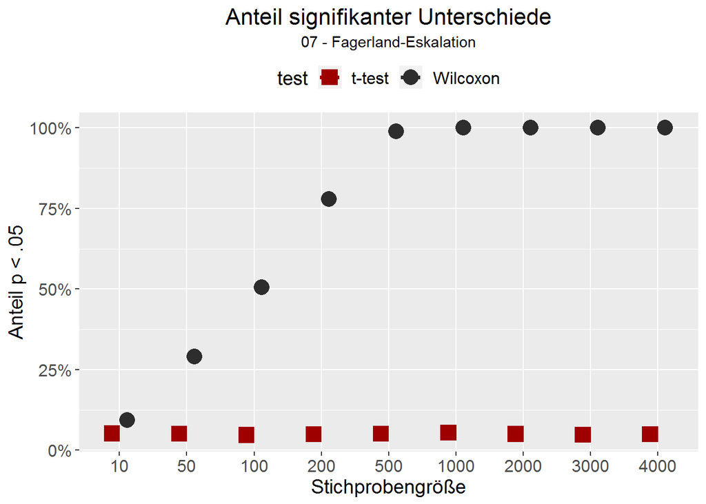